# Data Visualization in R

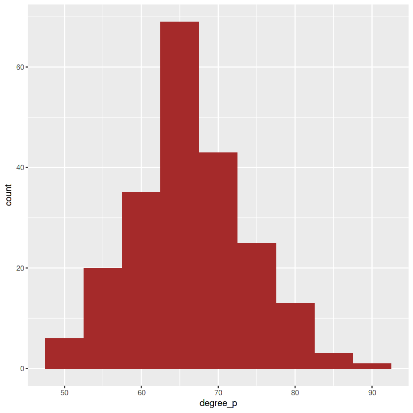

```r
base3 + geom_histogram(binwidth = 5, fill = "brown")
```

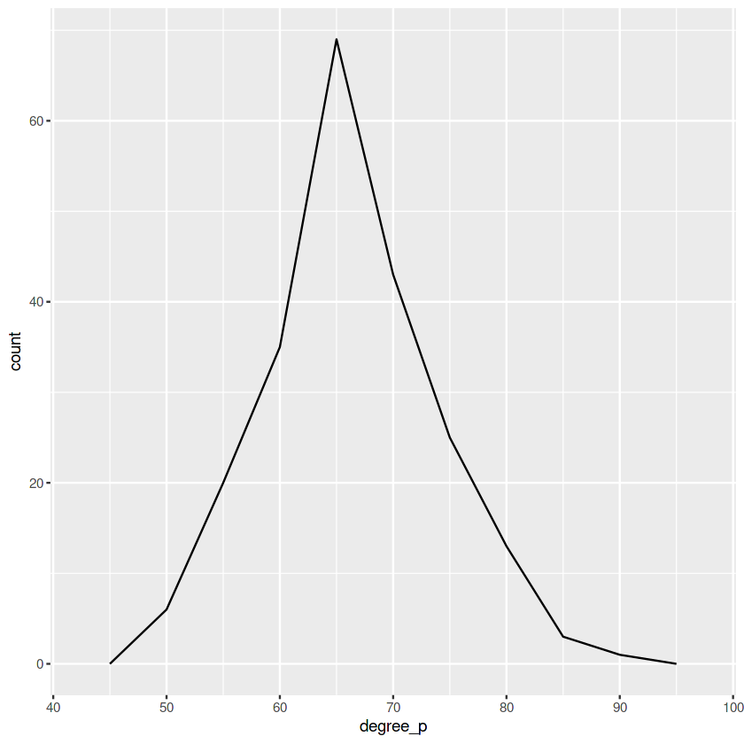

```r
base3 + geom_freqpoly(binwidth = 5) #  frequency polygons use lines instead of bars
```

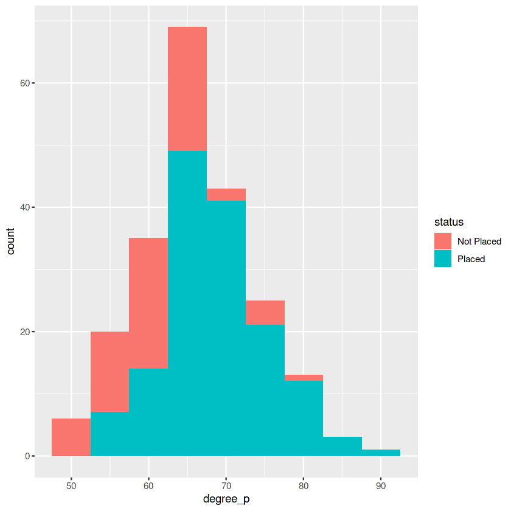

```r
base3 + geom_histogram(aes(fill = status), binwidth = 5)
```

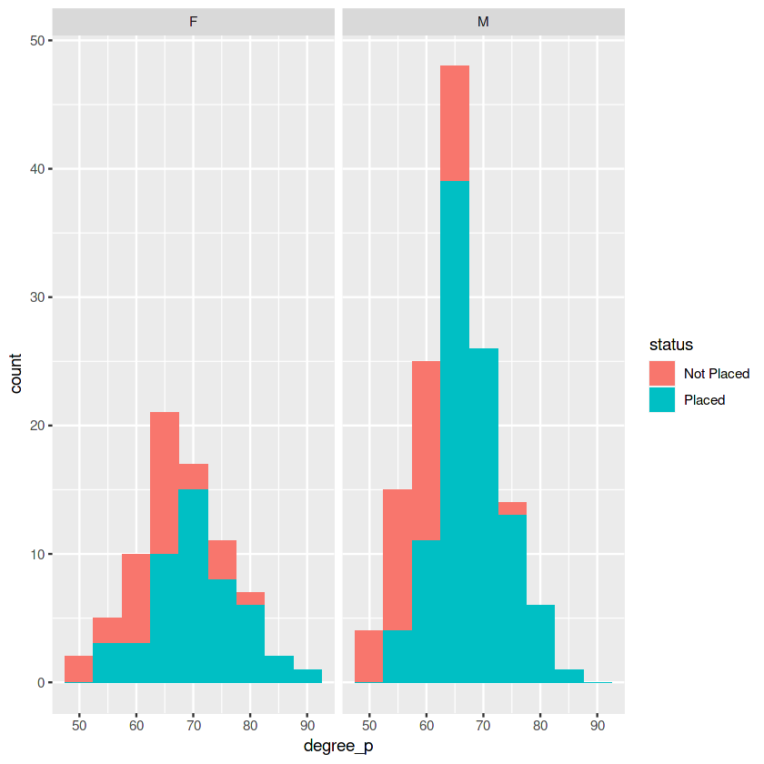

```r
base3 + geom_histogram(aes(fill = status), binwidth = 5) + facet_wrap(~gender)
```

# Density Plot

A Density Plot visualises the distribution of data over a continuous interval or time period. This chart is a variation of a Histogram that uses kernel smoothing to plot values, allowing for smoother distributions by smoothing out the noise. The peaks of a Density Plot help display where values are concentrated over the interval.

An advantage Density Plots have over Histograms is that they're better at determining the distribution shape because they're not affected by the number of bins used.

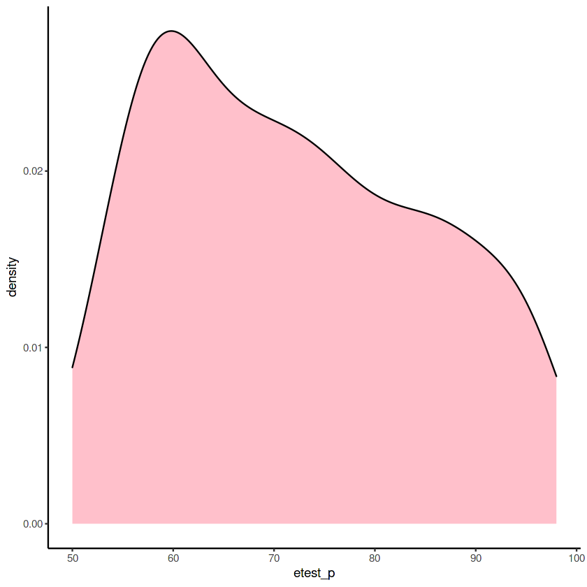

```r
# Density Plot
ggplot(placementgg) + geom_density(aes(etest_p), fill = "pink") + theme_classic()
```

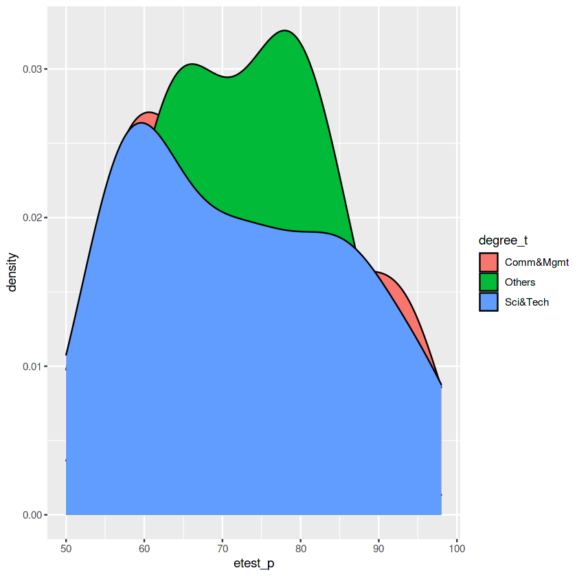

```r
ggplot(placementgg) + geom_density(aes(etest_p, fill = degree_t))
```

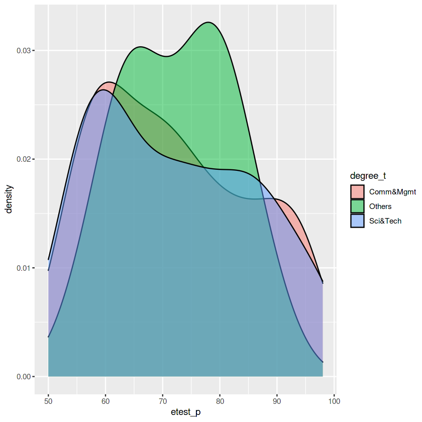

```r
ggplot(placementgg) + geom_density(aes(etest_p, fill = degree_t), alpha = 0.5) #alpha is used to make the colour lighter
```

# Box Plot

A box plot is a graphical representation of numerical data that can be used to **understand the variability of the data and the existence of outliers**. Box plot is designed by identifying the following descriptive statistics:

1. Lower Quartile, Median, and Upper Quartile
2. Lowest and highest value
3. Inter-quartile range (IQR)

The length of the box is equivalent to IQR. The dark line inside the box represents the median. The whisker of the box plot extends till Q1 – 1.5 IQR (or minimum value) and Q3 + 1.5 IQR (or maximum value); observations beyond these two limits are marked as dots and are potential outliers.

**Faceting:** Faceting is used to further drill down data and split the data by one or more variables, and then plot the subsets of the data altogether for optimum data visualization in R. To facet your plot by a single variable, use facet_wrap(). To facet your plot on the combination of two variables, add facet_grid() to your plot call

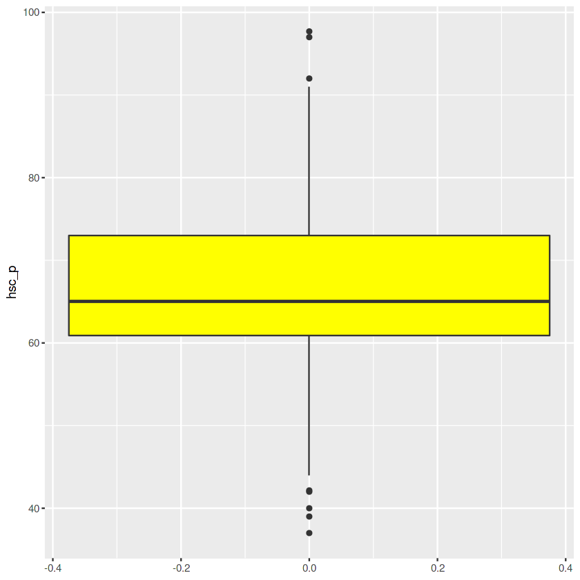

```r
# Box Plot
base4 <- ggplot(placementgg, aes(y = hsc_p))
base4 + geom_boxplot(fill = "yellow")
```

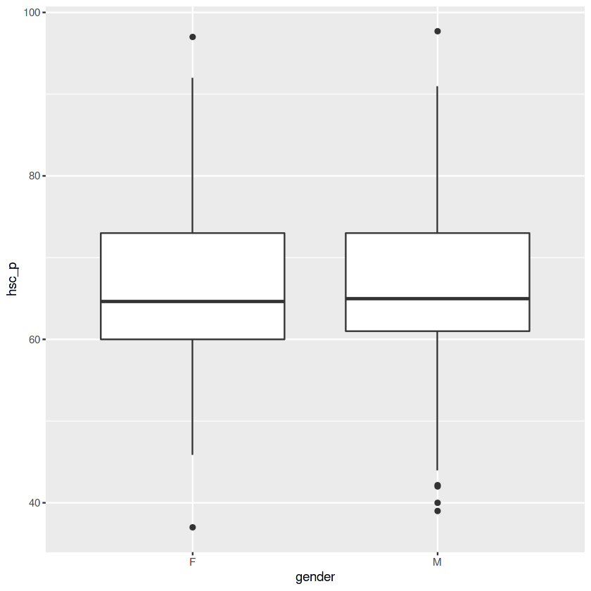

```r
base4 + geom_boxplot(aes(x = gender))
```

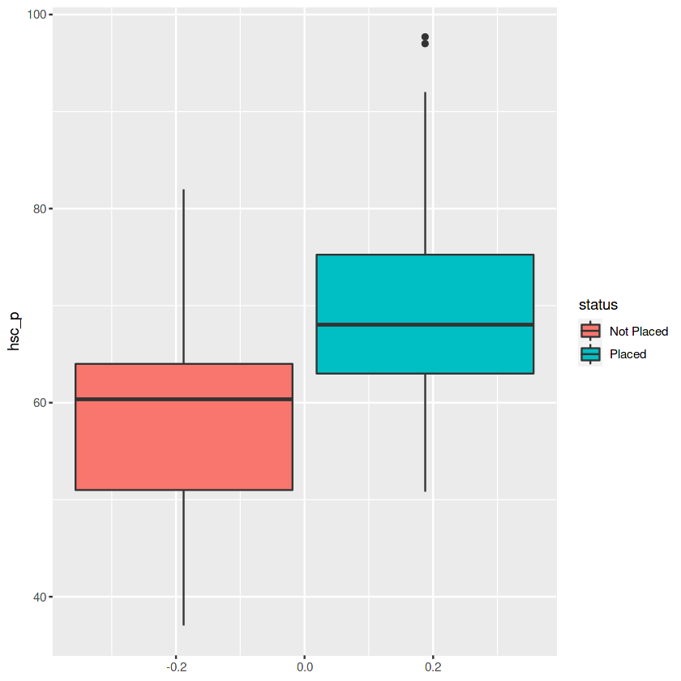

```r
base4 + geom_boxplot(aes(fill = status))
```

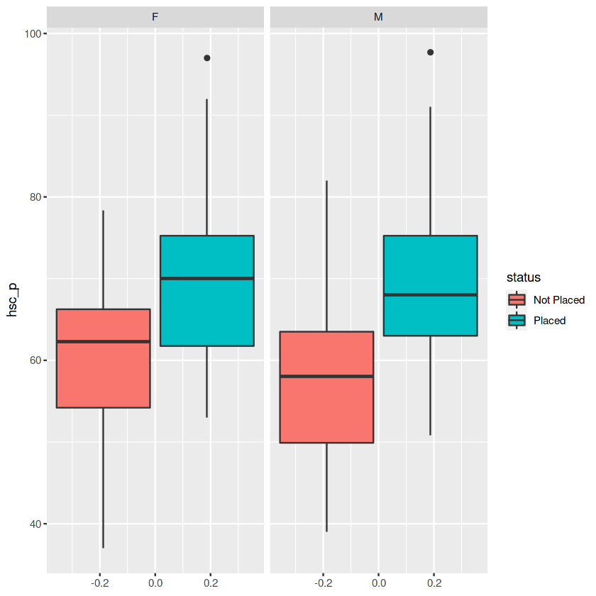

```r
base4 + geom_boxplot(aes(fill = status)) +
  facet_wrap(~gender)
```

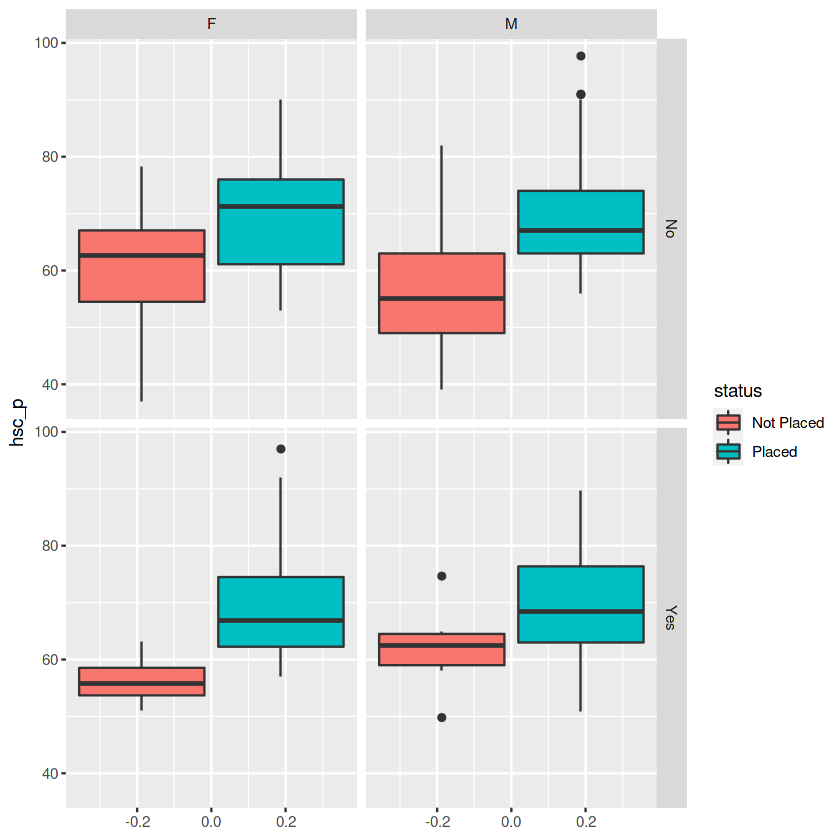

```r
base4 + geom_boxplot(aes(fill = status)) +
  facet_grid(workex~gender)
```

# Violin Plot

This chart is a combination of a Box Plot and a Density Plot that is rotated and placed on each side, to show the distribution shape of the data. geom_violin(), show a compact representation of the density of the distribution, highlighting the areas where more points are found.

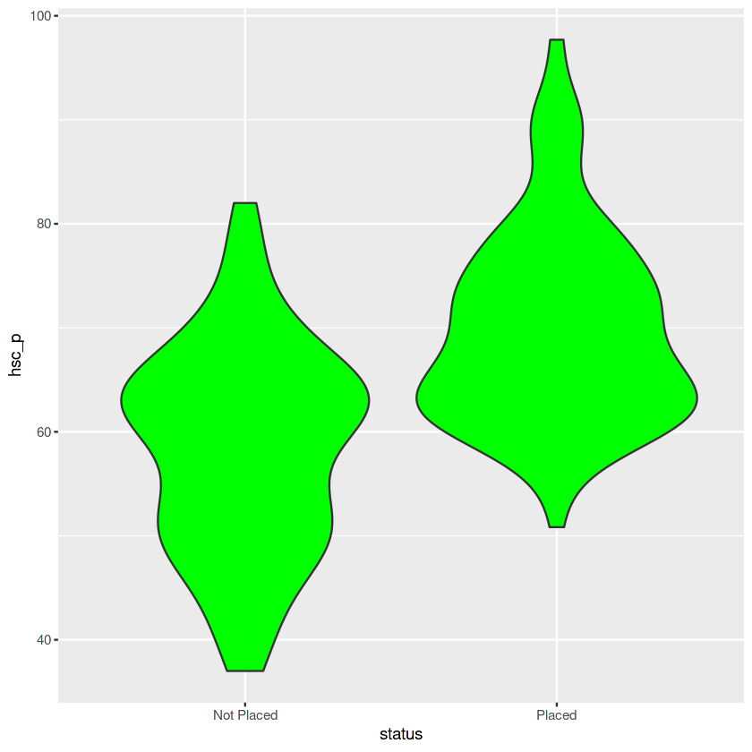

```r
#  Violin Plot
base4 + geom_violin(aes(x = status), fill = "green")
```

# Pie Chart

Pie chart is mainly used for categorical data. Pie Charts help show proportions and percentages between categories, by dividing a circle into proportional segments. Each arc length represents a proportion of each category, while the full circle represents the total sum of all the data, equal to 100%.

Pie charts are not recommended in the R documentation. A bar is recommended because people are able to measure length more accurately than volume.

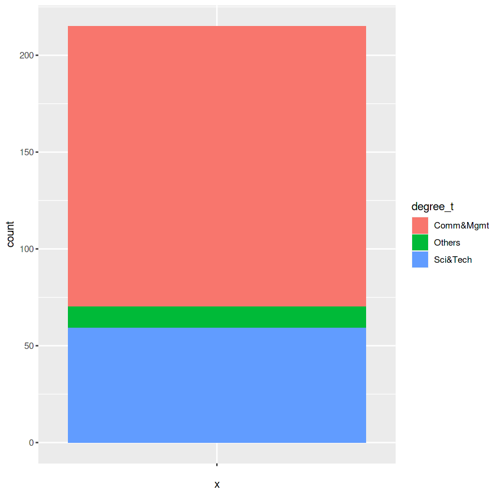

```r
# Pie Chart
piebar <- ggplot(placementgg, aes(x = " ", fill = degree_t))+ geom_bar(width = 1)
piebar
```

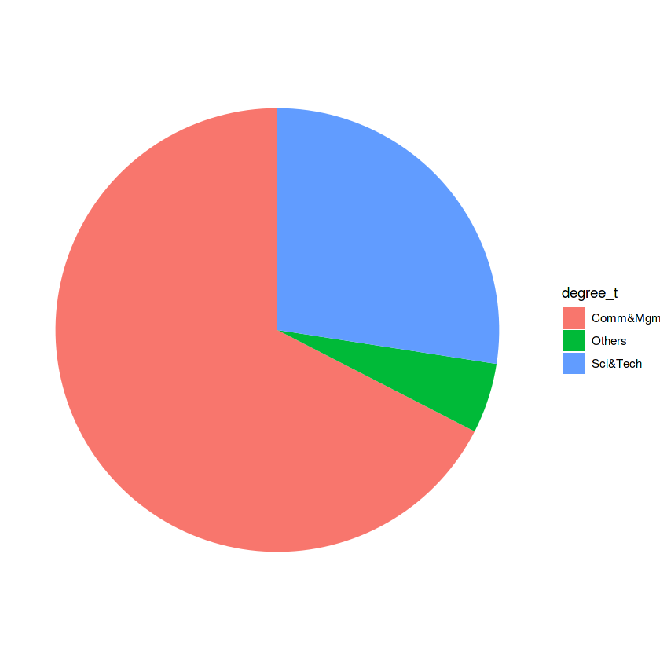

```r
piechart <- piebar + coord_polar("y") + theme_void()
piechart
```

# Heatmap

Heatmaps visualise data through variations in colouring. When applied to a tabular format, **Heatmaps are useful for cross-examining multivariate data**, through placing variables in the rows and columns and colouring the cells within the table. They use color to communicate relationships between data values that would be much harder to understand if presented numerically in a spreadsheet. Heatmaps are **good for detecting if any correlation exists between the variables**.

```r
# Heat Map
colnames(placementgg)
```

1. 'sl_no'

2. 'gender'

3. 'ssc_p'

4. 'ssc_b'

5. 'hsc_p'

6. 'hsc_b'

7. 'hsc_s'

8. 'degree_p'

9. 'degree_t'

10. 'workex'

11. 'etest_p'

12. 'specialisation'

13. 'mba_p'

14. 'status'

15. 'salary'

```r
placementgg_num <- placementgg[, c(3, 5, 8, 11)] # select only numeric
colnames(placementgg_num)
```

1. 'ssc_p'

2. 'hsc_p'

3. 'degree_p'

4. 'etest_p'

```r
corr_matrix <- round(cor(placementgg_num),2)
df_corr <- reshape2::melt(corr_matrix)
```

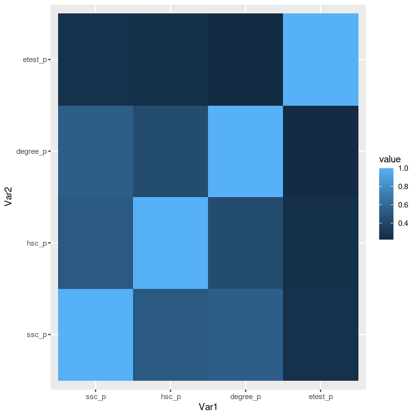

```r
ggplot(data = df_corr) +
  geom_tile(mapping = aes(x=Var1, y=Var2, fill=value))
```

# Scatterplot Matrix

A scatterplot matrix is a collection of scatterplots organized into a grid (or matrix). Each scatterplot shows the relationship between a pair of variables. We will be using the GGally R package which is an extension to ggplot2. It creates a matrix with scatterplots in the lower diagonal, densities on the diagonal and correlations written in the upper diagonal.

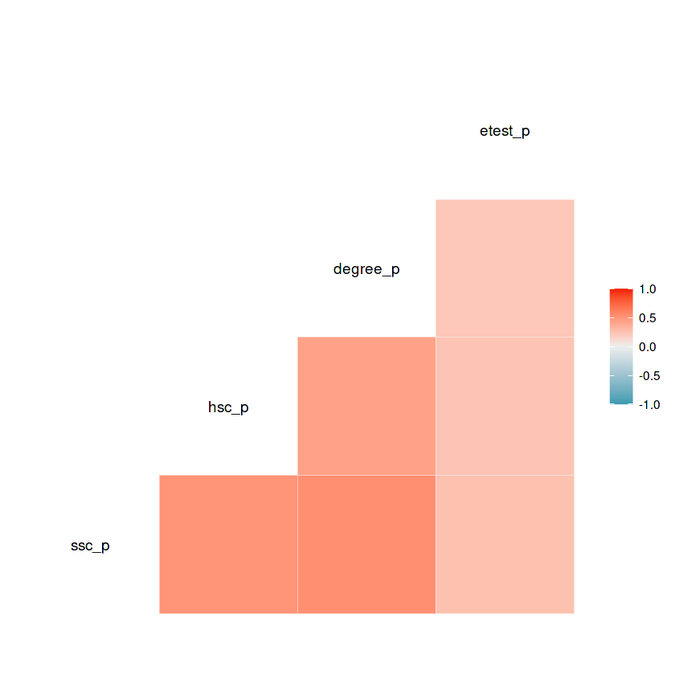

```r
# Pairwise scatterplot matrix
#install.packages("GGally")
library("GGally")
ggcorr(placementgg_num)
```

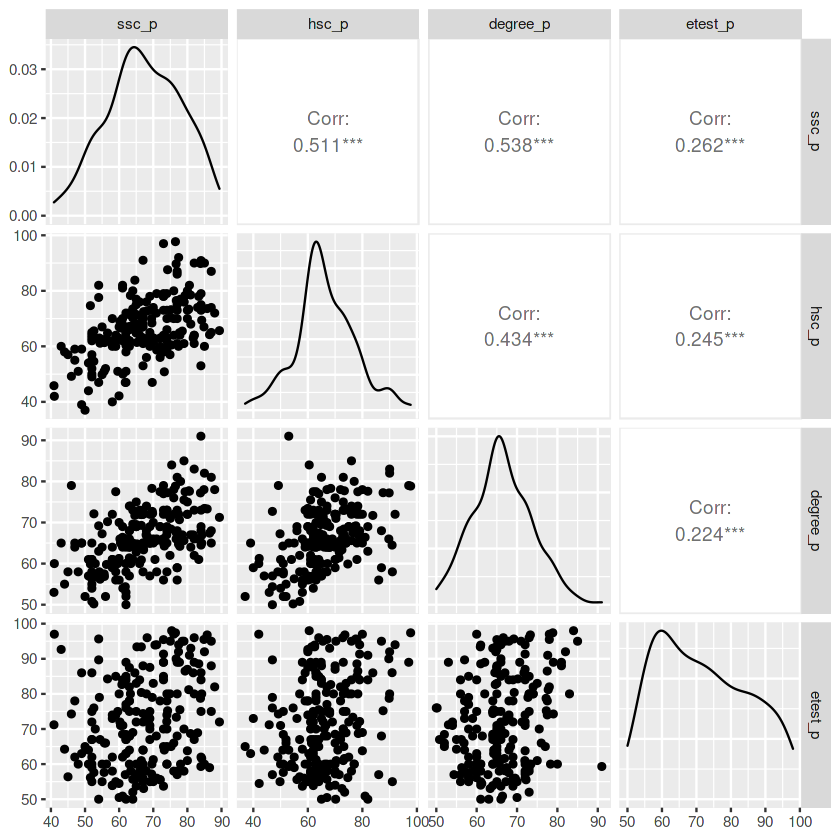

```r
ggpairs(placementgg_num) # correlogram
```

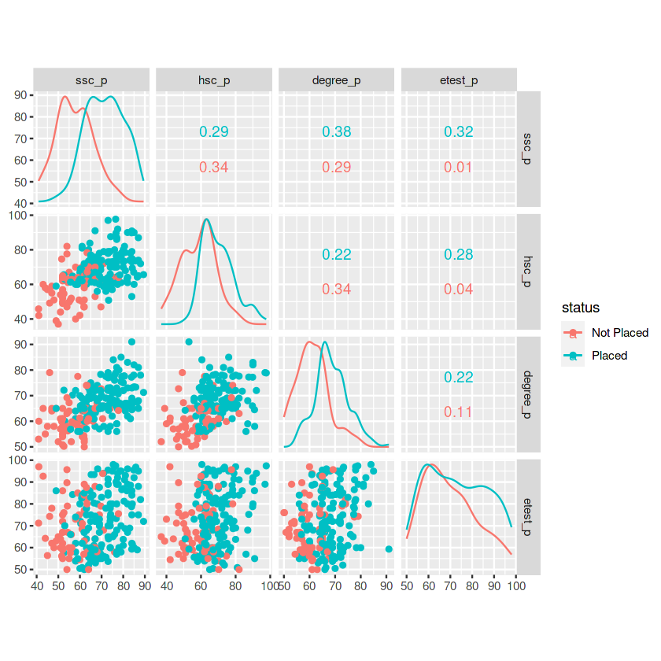

```r
ggscatmat(placementgg, columns = c(3,5,8,11), color = "status") # alternative
```

# Mosaic Plot

A mosaic plot (also known as a Marimekko diagram) is a graphical method for **visualizing data from two or more qualitative variables**. The mosaic plot starts as a square with length one. The square is divided first into horizontal bars whose widths are proportional to the probabilities associated with the first categorical variable. Then each bar is split vertically into bars that are proportional to the conditional probabilities of the second categorical variable. Additional splits can be made if required. Mosaic plots are constructed hierarchically, so the ordering of the variables is very important.

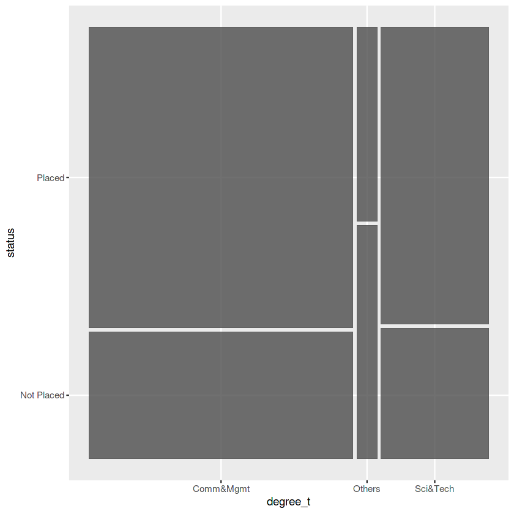

```r
# Mosaic Plot
# install.packages("ggmosaic")
library(ggmosaic)
base5 <- ggplot(placementgg)
base5 + geom_mosaic(aes(x = product(status, degree_t)))
```

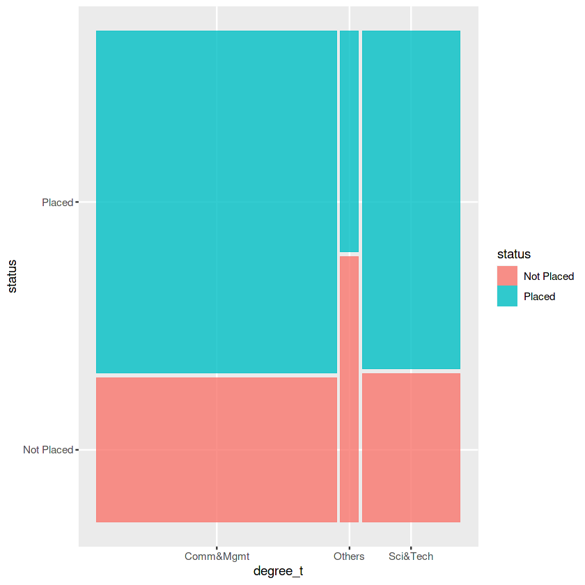

```r
base5 + geom_mosaic(aes(x = product(status, degree_t), fill = status))
```

# Quick Plot

In some cases, we will want to create a quick plot with a minimum of typing. In these cases we may prefer to use qplot() over ggplot(). qplot() lets us deﬁne a plot in a single call, picking a geom by default if we don’t supply one. To use it, we have to provide a set of aesthetics and a data set.

```r
# quick plot
qplot(ssc_p, hsc_p, data = placementgg)
```

[output not shown]

# Saving a plot

ggsave() is a convenient function for saving a plot. It defaults to saving the last plot that you displayed, using the size of the current graphics device. It also guesses the type of graphics device from the extension. You can also control the width, height and dpi using the additional arguments. Alternatively, use the Export option available under Plots tab.

```r
# saving a plot
ggsave("myplot.pdf")
ggsave("myplot.png")
```